# Assignment 9- Supervised Machine Learning

Marko Konte

8/1/2019

## Data Preparation

Next we will take the dataset red in above and apply changes to it to be able to run random forest models and see how they perform based on sampling techniques. Since we will be using a random forest model, we will not be scaling the data. Capping and Flooring will not be done because it was very computationally expensive on such a dataset.

```r
###Seperating and removing response variable from the dataset
##Specify the response variable
str(data)
```

```
## 'data.frame':    80000 obs. of  379 variables:
##  $ X           : int  1 2 3 4 5 6 7 8 9 10 ...
##  $ id          : int  1 2 3 4 5 6 7 8 9 10 ...
##  $ loan_default: int  1 0 0 0 0 1 1 0 0 0 ...
##  $ AP001       : int  31 27 33 34 47 32 23 40 25 27 ...
##  $ AP002       : int  2 1 1 2 2 1 1 2 1 2 ...
##  $ AP003       : int  1 1 4 4 1 1 3 3 3 4 ...
##  $ AP004       : int  12 12 12 12 12 12 12 3 12 12 ...
##  $ AP005       : Factor w/ 55057 levels "3/22/2017 15:12",..: 52778 12039 46676 53398 52964 20517 21800 30539 9529 44707 ...
##  $ AP006       : Factor w/ 4 levels "android","api",..: 4 3 3 1 3 3 4 3 3 4 ...
##  $ AP007       : int  3 5 4 5 4 5 1 5 5 5 ...
##  $ AP008       : int  3 4 2 5 4 4 1 5 5 5 ...
##  $ AP009       : int  1 0 0 0 1 0 0 1 1 0 ...
##  $ TD001       : int  1 2 2 0 2 2 2 1 4 4 ...
##  $ TD002       : int  1 0 1 0 0 1 0 1 1 1 ...
```

[output cut: 86 more lines]

```r
response <- "loan_default"
##Make the response variable a categorical variable
data[[response]] <- as.factor(data[[response]])

##Remove date variable since anydate was causing too many NA's
data <- data[,-8]

##Apps
data$AP006 <- as.numeric(data$AP006)

##Tanslation for apps
#1 - Android
#2 - api
#3 - h5
#4 - ios

##Remove NA's - replacing with 0 since using Mice took a lot of computational power
data[is.na(data)] <- 0

#Creating the predictor variable
predictors <- setdiff(names(data), c(response))

#Creating Train, Test, and Validation dataset

h2o.init()
```

```
##  Connection successful!
##
## R is connected to the H2O cluster:
##     H2O cluster uptime:         7 hours 1 minutes
##     H2O cluster timezone:       America/New_York
##     H2O data parsing timezone:  UTC
##     H2O cluster version:        3.24.0.5
##     H2O cluster version age:    1 month and 15 days
##     H2O cluster name:           H2O_started_from_R_marko_jph146
##     H2O cluster total nodes:    1
##     H2O cluster total memory:   1.50 GB
##     H2O cluster total cores:    4
##     H2O cluster allowed cores:  4
##     H2O cluster healthy:        TRUE
##     H2O Connection ip:          localhost
##     H2O Connection port:        54321
##     H2O Connection proxy:       NA
##     H2O Internal Security:      FALSE
##     H2O API Extensions:         Amazon S3, Algos, AutoML, Core V3, Core V4
##     R Version:                  R version 3.6.0 (2019-04-26)
```

```r
h2odata <- as.h2o(data)
splits <- h2o.splitFrame(
  data = h2odata,
  ratios = c(0.3,0.3),   # the ratios should sum up to to be less than 1.0.
  destination_frames = c("train", "valid", "test"), seed = 1234
)
train <- splits[[1]]
valid <- splits[[2]]
test  <- splits[[3]]
```

## Running Random forest model

We will first run the model on all variables in the dataset (except date) without any over or under sampling technique.

The performance metrics we will be looking at are:

AUC: Measures the true positive rate in relation to the false positive rate. This metric seeks to show the performance of the. Standing for ‘Area Under the Curve’, it measures the area under the FP/(FP+TN)

MSE: Measures the squared error of the prediction per each point. This means that for each prediction, the measure calculates the difference between the predicting value and the targer variable of the model. It is a simple goodness of fit measure however prone to be heavily impacted by outliers.

RMSE: This is the square root of the MSE metric. In essence, it produces a similar measure of performance in that the metric shows the amount of error that the model has in relation to predicting the response variable. The square root however to scale the errors and therefore show a more normalized result.

LogLoss: Measures a binary (logarithmic) performance of the predictor to the response variable. It is a useful predictor to apply the ‘uncertainty’ of the model to the overall dataset. This is one of the more effective measurments in logistic regression.

```r
#Seeing the response variables

h2o.table(train[response])
```

```
##   loan_default Count
## 1            0 19331
## 2            1  4688
##
## [2 rows x 2 columns]
```

```r
#1 based on the basic training model- so 1 to 1
rf_model <- h2o.randomForest(
  training_frame = train,
  validation_frame = valid,
  x=predictors,
  y='loan_default',
  model_id = "rf_model",
  ntrees = 2000, #2000 is recommended
  max_depth = 30, #30 is recommended
  stopping_rounds = 2,
  stopping_tolerance = 1e-2,
  score_each_iteration = T,
  seed=1234)
## Get the AUC on the validation set
h2o.auc(h2o.performance(rf_model, newdata = valid))
```

```
## [1] 0.6388367
```

```r
## Get the AUC on the test set
h2o.auc(h2o.performance(rf_model, newdata = test))
```

```
## [1] 0.6372219
```

```r
#Performance metrics
h2o.performance(rf_model)
```

```
## H2OBinomialMetrics: drf
## ** Reported on training data. **
## ** Metrics reported on Out-Of-Bag training samples **
##
## MSE:  0.1628664
## RMSE:  0.4035671
## LogLoss:  0.8236133
## Mean Per-Class Error:  0.4280819
## AUC:  0.6018085
## pr_auc:  0.2643594
## Gini:  0.203617
##
## Confusion Matrix (vertical: actual; across: predicted) for F1-optimal threshold:
##            0     1    Error          Rate
## 0       8640 10691 0.553050  =10691/19331
## 1       1421  3267 0.303114    =1421/4688
## Totals 10061 13958 0.504267  =12112/24019
##
## Maximum Metrics: Maximum metrics at their respective thresholds
##                         metric threshold    value idx
## 1                       max f1  0.152674 0.350424 266
## 2                       max f2  0.000000 0.548035 399
## 3                 max f0point5  0.322132 0.291570 141
## 4                 max accuracy  0.822653 0.805029   6
## 5                max precision  1.000000 1.000000   0
## 6                   max recall  0.000000 1.000000 399
## 7              max specificity  1.000000 1.000000   0
## 8             max absolute_mcc  0.300005 0.122348 154
## 9   max min_per_class_accuracy  0.201222 0.565700 225
## 10 max mean_per_class_accuracy  0.196398 0.576377 229
##
## Gains/Lift Table: Extract with `h2o.gainsLift(<model>, <data>)` or `h2o.gainsLift(<model>, valid=<T/F>, xval=<T/F>)`
```

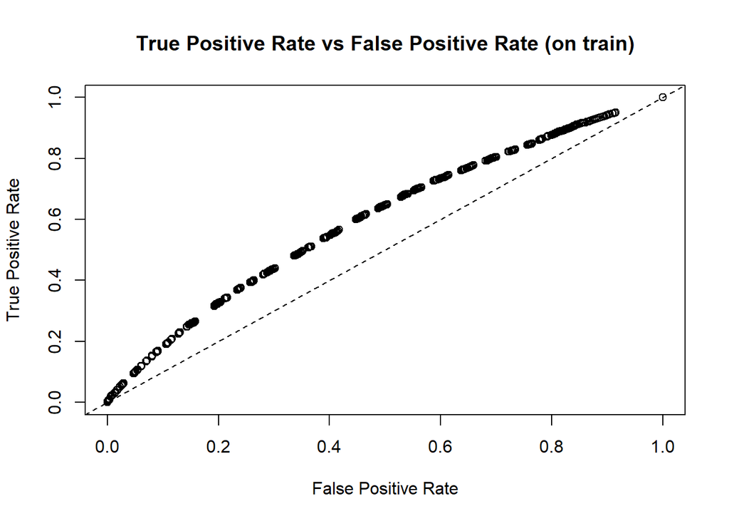

```r
#1st chart
plot(h2o.performance(rf_model), type='roc')
```

### Summary

**AUC Validation: .6388**

**AUC Test: .63722**

### MSE

0.1610644

### RMSE

0.4013283

### Logloss

0.8265147

### Gini

0.2306827

## 1 to 2 Sample

In order to run a sampling ratio on a random forest model, the rate_per_class parameter is used. Since we have one response variable in this dataset, the second variable needs to set for the desired ratio.

The percentage of response to overall instances in the dataset is 0.2400794, therefore this will be monitored in relation to the best performing model approaches.

```r
# try using the `sample_rate_per_class` parameter:
# downsample the Class 2, and leave the rest the same
##2 based on the basic training model- so 1 to 2
rate_per_class_list <- c(.5, .5)
rf_model2 <- h2o.randomForest(
  training_frame = train,
  validation_frame = valid,
  x=predictors,
  y='loan_default',
  model_id = "rf_model2",
  ntrees = 200, #2000 is recommended
  max_depth = 10, #30 is recommended
  stopping_rounds = 2,
  stopping_tolerance = 1e-2,
  score_each_iteration = T,
  seed=1234,
  sample_rate_per_class = rate_per_class_list)
## Get the AUC on the validation set
h2o.auc(h2o.performance(rf_model2, newdata = valid))
```

```
## [1] 0.6440835
```

```r
## Get the AUC on the test set
h2o.auc(h2o.performance(rf_model2, newdata = test))
```

```
## [1] 0.6421456
```

```r
Rf_predictions<-h2o.predict(object = rf_model2,newdata = valid)
#Performance metrics
h2o.performance(rf_model2)
```

```
## H2OBinomialMetrics: drf
## ** Reported on training data. **
## ** Metrics reported on Out-Of-Bag training samples **
##
## MSE:  0.1558131
## RMSE:  0.3947317
## LogLoss:  0.5274721
## Mean Per-Class Error:  0.4168049
## AUC:  0.6152766
## pr_auc:  0.26778
## Gini:  0.2305533
##
## Confusion Matrix (vertical: actual; across: predicted) for F1-optimal threshold:
##            0     1    Error          Rate
## 0       8762 10492 0.544926  =10492/19254
## 1       1347  3319 0.288684    =1347/4666
## Totals 10109 13811 0.494941  =11839/23920
##
## Maximum Metrics: Maximum metrics at their respective thresholds
##                         metric threshold    value idx
## 1                       max f1  0.157632 0.359257 283
## 2                       max f2  0.086915 0.549102 362
## 3                 max f0point5  0.231762 0.298084 207
## 4                 max accuracy  0.820513 0.804724   4
## 5                max precision  0.671929 0.463918  19
## 6                   max recall  0.000000 1.000000 399
## 7              max specificity  1.000000 0.999117   0
## 8             max absolute_mcc  0.184638 0.138840 251
## 9   max min_per_class_accuracy  0.177386 0.584865 259
## 10 max mean_per_class_accuracy  0.179646 0.586694 257
##
## Gains/Lift Table: Extract with `h2o.gainsLift(<model>, <data>)` or `h2o.gainsLift(<model>, valid=<T/F>, xval=<T/F>)`
```

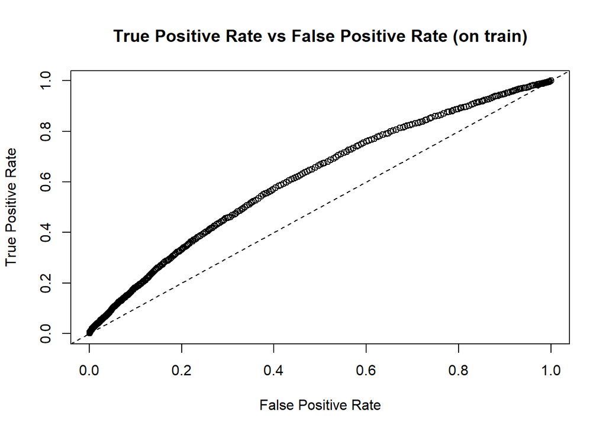

```r
#2nd chart
plot(h2o.performance(rf_model2), type='roc')
```

### Summary

By doing applying an undersampling technique of 1 to 2 as opposed to one to one there was an improvement in the AUC performance of .005.

**AUC Val: .64408**

**AUC Test: .6421456**

### MSE

0.1588668

### RMSE

0.398581

### Logloss

0.6325737

### Gini

0.2244589

## 1:3 sampling

```r
##3 based on the basic training model- so 1 to 3
rate_per_class_list <- c(.33, .67)
rf_model3 <- h2o.randomForest(
  training_frame = train,
  validation_frame = valid,
  x=predictors,
  y='loan_default',
  model_id = "rf_model3",
  ntrees = 2000,
  max_depth = 30,
  stopping_rounds = 2,
  stopping_tolerance = 1e-2,
  score_each_iteration = T,
  seed=1234,
  sample_rate_per_class = rate_per_class_list)
## Get the AUC on the validation set
h2o.auc(h2o.performance(rf_model3, newdata = valid))
```

```
## [1] 0.636485
```

```r
## Get the AUC on the test set
h2o.auc(h2o.performance(rf_model3, newdata = test))
```

```
## [1] 0.6365295
```

```r
Rf_predictions<-h2o.predict(object = rf_model3,newdata = valid)
Rf_predictions
```

```
##   predict        p0        p1
## 1       1 0.6359127 0.3640873
## 2       1 0.5932692 0.4067308
## 3       1 0.5500000 0.4500000
## 4       0 0.7500000 0.2500000
## 5       1 0.5000000 0.5000000
## 6       0 0.7500000 0.2500000
##
## [23925 rows x 3 columns]
```

```r
#Performance metrics
h2o.performance(rf_model3)
```

```
## H2OBinomialMetrics: drf
## ** Reported on training data. **
## ** Metrics reported on Out-Of-Bag training samples **
##
## MSE:  0.184546
## RMSE:  0.4295881
## LogLoss:  0.9944515
## Mean Per-Class Error:  0.4061001
## AUC:  0.5980141
## pr_auc:  0.3075414
## Gini:  0.1960281
##
## Confusion Matrix (vertical: actual; across: predicted) for F1-optimal threshold:
##            0    1    Error         Rate
## 0      13531 5800 0.300036  =5800/19331
## 1       2400 2286 0.512164   =2400/4686
## Totals 15931 8086 0.341425  =8200/24017
##
## Maximum Metrics: Maximum metrics at their respective thresholds
##                         metric threshold    value idx
## 1                       max f1  0.399999 0.357971 150
## 2                       max f2  0.000000 0.547929 399
## 3                 max f0point5  0.500001 0.353788 101
## 4                 max accuracy  0.749989 0.811217  26
## 5                max precision  1.000000 0.965517   0
## 6                   max recall  0.000000 1.000000 399
## 7              max specificity  1.000000 0.999897   0
## 8             max absolute_mcc  0.500001 0.197118 101
## 9   max min_per_class_accuracy  0.333329 0.554394 191
## 10 max mean_per_class_accuracy  0.500001 0.598535 101
##
## Gains/Lift Table: Extract with `h2o.gainsLift(<model>, <data>)` or `h2o.gainsLift(<model>, valid=<T/F>, xval=<T/F>)`
```

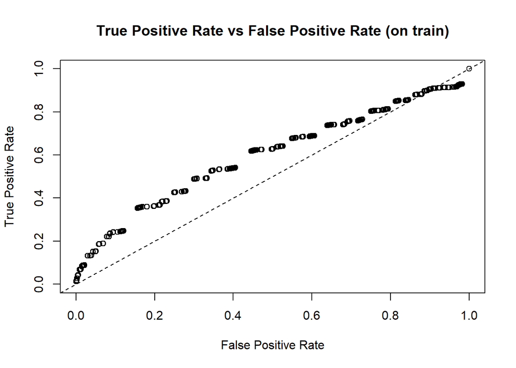

```r
#3rd chart
plot(h2o.performance(rf_model3), type='roc')
```

### MSE

0.1712493

### RMSE

0.4138228

### Logloss

0.6176847

### Gini

0.2581684

## 1:4 Sample

```r
##4 based on the basic training model- so 1 to 4
rate_per_class_list <- c(.25, .75)
rf_model4 <- h2o.randomForest(
  training_frame = train,
  validation_frame = valid,
  x=predictors,
  y='loan_default',
  model_id = "rf_model2",
  ntrees = 2000, #2000 is recommended
  max_depth = 30, #30 is recommended
  stopping_rounds = 2,
  stopping_tolerance = 1e-2,
  score_each_iteration = T,
  seed=1234,
  sample_rate_per_class = rate_per_class_list)
## Get the AUC on the validation set
h2o.auc(h2o.performance(rf_model4, newdata = valid))
```

```
## [1] 0.6390547
```

```r
## Get the AUC on the test set
h2o.auc(h2o.performance(rf_model4, newdata = test))
```

```
## [1] 0.6347006
```

```r
Rf_predictions<-h2o.predict(object = rf_model4,newdata = valid)
#Performance metrics
h2o.performance(rf_model4)
```

```
## H2OBinomialMetrics: drf
## ** Reported on training data. **
## ** Metrics reported on Out-Of-Bag training samples **
##
## MSE:  0.2162214
## RMSE:  0.4649961
## LogLoss:  1.203287
## Mean Per-Class Error:  0.3829305
## AUC:  0.5926309
## pr_auc:  0.2963019
## Gini:  0.1852619
##
## Confusion Matrix (vertical: actual; across: predicted) for F1-optimal threshold:
##            0    1    Error         Rate
## 0      13730 5601 0.289742  =5601/19331
## 1       2223 2446 0.476119   =2223/4669
## Totals 15953 8047 0.326000  =7824/24000
##
## Maximum Metrics: Maximum metrics at their respective thresholds
##                         metric threshold    value idx
## 1                       max f1  0.499998 0.384712 133
## 2                       max f2  0.000006 0.547029 399
## 3                 max f0point5  0.666666 0.419274  55
## 4                 max accuracy  0.800021 0.820458  22
## 5                max precision  1.000000 0.983051   0
## 6                   max recall  0.000006 1.000000 399
## 7              max specificity  1.000000 0.999690   0
## 8             max absolute_mcc  0.749991 0.260545  33
## 9   max min_per_class_accuracy  0.413381 0.558578 184
## 10 max mean_per_class_accuracy  0.499998 0.617070 133
##
## Gains/Lift Table: Extract with `h2o.gainsLift(<model>, <data>)` or `h2o.gainsLift(<model>, valid=<T/F>, xval=<T/F>)`
```

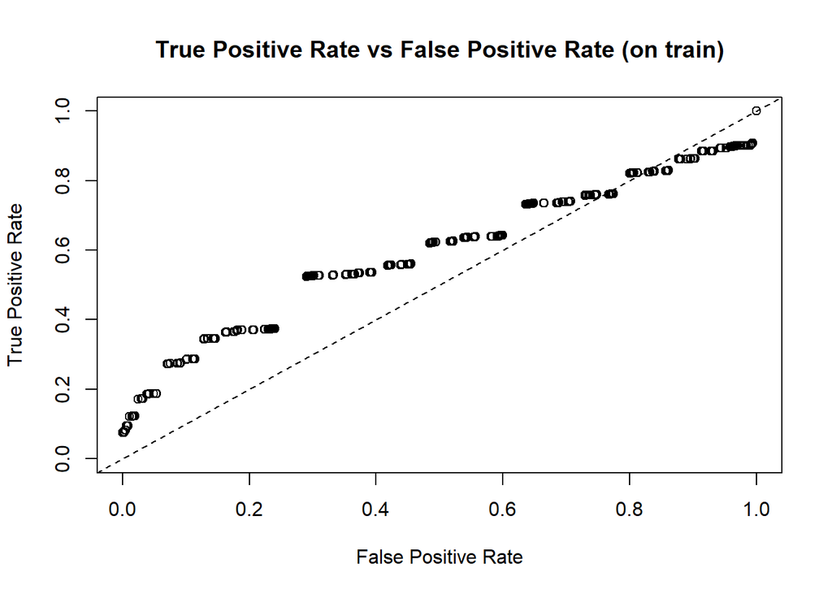

```r
#4th chart- .25, .75 sample
plot(h2o.performance(rf_model4), type='roc')
```

### Summary

**AUC Val: .6390547**

**AUC Test: .6347006**

### MSE

0.2157924

### RMSE

0.4645346

### Logloss

1.020053

### Gini

0.2089649

## Testing out further extremes with sampling figures

Next we will do a similar process of testing extremes of 1 to 9 undersampling and 9 to 1 oversampling of the data. Next we will run a model of a 1 to 3 sample model with the best performing grid model (to be run later).

```r
#5th chart- .1 .9 sample
rate_per_class_list <- c(.1, .9)
rf_model5 <- h2o.randomForest(
  training_frame = train,
  validation_frame = valid,
  x=predictors,
  y='loan_default',
  model_id = "rf_model5",
  ntrees = 2000,
  max_depth = 30,
  stopping_rounds = 2,
  stopping_tolerance = 1e-2,
  score_each_iteration = T,
  seed=1234,
  sample_rate_per_class = rate_per_class_list)
## Get the AUC on the validation set
h2o.auc(h2o.performance(rf_model5, newdata = valid))
```

```
## [1] 0.6370046
```

```r
## Get the AUC on the test set
h2o.auc(h2o.performance(rf_model5, newdata = test))
```

```
## [1] 0.6383636
```

```r
Rf_predictions<-h2o.predict(object = rf_model5,newdata = valid)
```

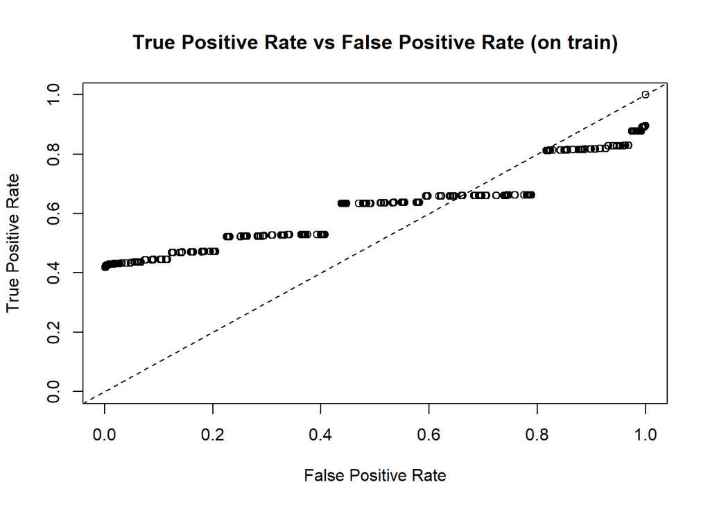

```r
##Performance Stats
#MSE:  0.3765519
#RMSE:  0.6136383
#LogLoss:  1.631784
#Gini:  0.2327069


#5th chart- sample
plot(h2o.performance(rf_model5), type='roc')
```

```r
#6th chart- .9 .1 sample
rate_per_class_list <- c(.9, .1)
rf_model6 <- h2o.randomForest(
  training_frame = train,
  validation_frame = valid,
  x=predictors,
  y='loan_default',
  model_id = "rf_model6",
  ntrees = 2000,
  max_depth = 30,
  stopping_rounds = 2,
  stopping_tolerance = 1e-2,
  score_each_iteration = T,
  seed=1234,
  sample_rate_per_class = rate_per_class_list)
## Get the AUC on the validation set
h2o.auc(h2o.performance(rf_model6, newdata = valid))
```

```
## [1] 0.5943416
```

```r
## Get the AUC on the test set
h2o.auc(h2o.performance(rf_model6, newdata = test))
```

```
## [1] 0.5940416
```

```r
Rf_predictions<-h2o.predict(object = rf_model6,newdata = valid)
```

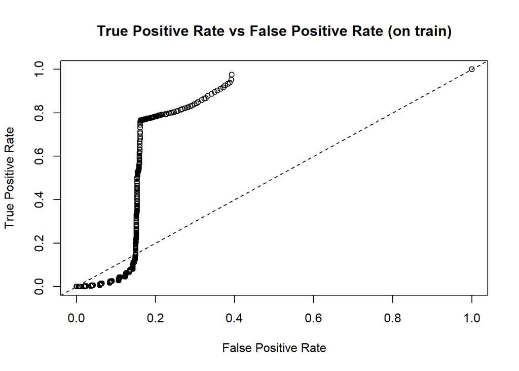

```r
### 9,1

#MSE:  0.1827278
#RMSE:  0.4274668
#LogLoss:  1.197687
#Gini:  0.4487018

#.9, .1- sample
plot(h2o.performance(rf_model6), type='roc')
```

```r
#7th model- .33 .67 sample with maximum ntrees from grid and lowered depth value
rate_per_class_list <- c(.33, .67)
rf_model7 <- h2o.randomForest(
  training_frame = train,
  validation_frame = valid,
  x=predictors,
  y='loan_default',
  model_id = "rf_model6",
  ntrees = 150,
  max_depth = 5,
  stopping_rounds = 2,
  stopping_tolerance = 1e-2,
  score_each_iteration = T,
  seed=1234,
  sample_rate_per_class = rate_per_class_list)
## Get the AUC on the validation set
h2o.auc(h2o.performance(rf_model7, newdata = valid))
```

```
## [1] 0.6382297
```

```r
## Get the AUC on the test set
h2o.auc(h2o.performance(rf_model7, newdata = test))
```

```
## [1] 0.6403903
```

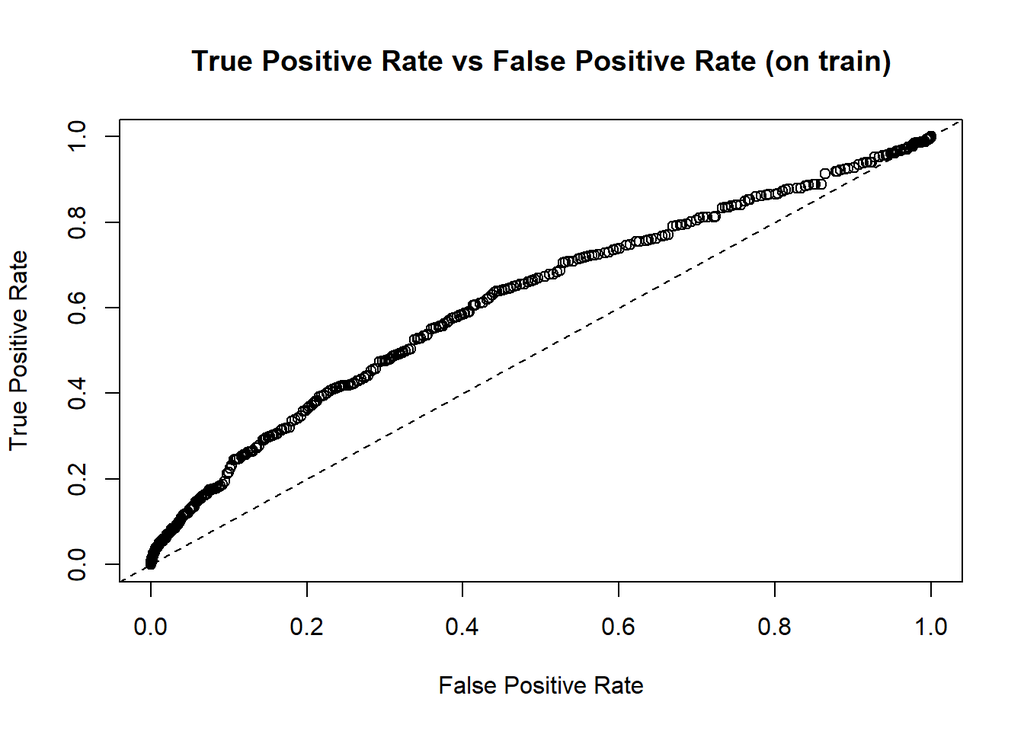

```r
# Best from grid
#MSE:  0.4011607
#RMSE:  0.6333725
#LogLoss:  1.027258
#Gini:  0.308109

#.33, .67- sample
plot(h2o.performance(rf_model7), type='roc')
```

## Variables identified in Assignment 2

In Assignment 2 of this semester we used this dataset and applied the lasso model in order to identify the most significant variables in the data. Next we will isolate these variables and see how they perform on the Random forest model.

```r
#Using predictors from the first assignment

data2 <- select(data, loan_default, AP001,AP002,AP003,AP004,AP006, AP007,
                AP008, CD123, TD005, TD009, TD013, CR007,
                CR008, CR015, CR016, CR017, CR019)

predictors2 <- setdiff(names(data2), c(response))

h2odata2 <- as.h2o(data2)
splits2 <- h2o.splitFrame(
  data = h2odata2,
  ratios = c(0.3,0.3),   # the ratios should sum up to to be less than 1.0.
  destination_frames = c("train", "valid", "test"), seed = 1234
)
train2 <- splits2[[1]]
valid2 <- splits2[[2]]
test2  <- splits2[[3]]

#Putting it on the best performing model with all variables
rate_per_class_list <- c(.33, .67)
rf_model8 <- h2o.randomForest(
  training_frame = train2,
  validation_frame = valid2,
  x=predictors2,
  y='loan_default',
  model_id = "rf_model2",
  ntrees = 2000,
  max_depth = 30,
  stopping_rounds = 2,
  stopping_tolerance = 1e-2,
  score_each_iteration = T,
  seed=1234,
  sample_rate_per_class = rate_per_class_list)
## Get the AUC on the validation set
h2o.auc(h2o.performance(rf_model8, newdata = valid2))
```

```
## [1] 0.6429309
```

```r
## Get the AUC on the testtest
h2o.auc(h2o.performance(rf_model8, newdata = test2))
```

```
## [1] 0.6402909
```

```r
Rf_predictions<-h2o.predict(object = rf_model8,newdata = valid2)
```

## Summary

**AUC Val: 0.6429309**

**AUC Test: 0.6402909**

### MSE

0.1712493

### RMSE

0.4138228

### Logloss

0.6176847

### Gini

0.2581684

## Putting all four AUC charts into one

We will plot two charts:

1. Collective AUC chart of the 4 sampling models created
2. Additional Extremes Tested and Assignment 2 variables

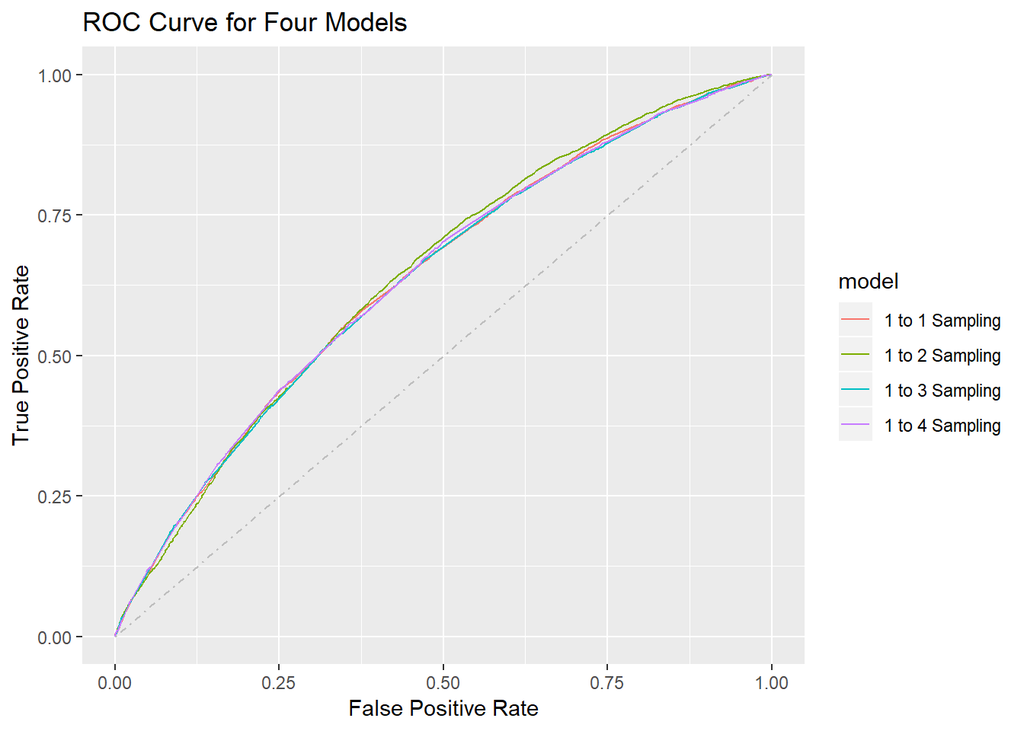

```r
#Plotting different sampling approaches
list(rf_model,rf_model2,rf_model3,rf_model4) %>%
  # map a function to each element in the list
  map(function(x) x %>% h2o.performance(valid=T) %>%
        # from all these 'paths' in the object
        .@metrics %>% .$thresholds_and_metric_scores %>%
        # extracting true positive rate and false positive rate
        .[c('tpr','fpr')] %>%
        # add (0,0) and (1,1) for the start and end point of ROC curve
        add_row(tpr=0,fpr=0,.before=T) %>%
        add_row(tpr=0,fpr=0,.before=F)) %>%
  # add a column of model name for future grouping in ggplot2
  map2(c('1 to 1 Sampling','1 to 2 Sampling','1 to 3 Sampling','1 to 4 Sampling'),
       function(x,y) x %>% add_column(model=y)) %>%
  # reduce four data.frame to one
  reduce(rbind) %>%
  # plot fpr and tpr, map model to color as grouping
  ggplot(aes(fpr,tpr,col=model))+
  geom_line()+
  geom_segment(aes(x=0,y=0,xend = 1, yend = 1),linetype = 4,col='grey')+
  xlab('False Positive Rate')+
  ylab('True Positive Rate')+
  ggtitle('ROC Curve for Four Models')
```

[figure not shown]

```r
#Plotting the 4 additional extreme models
list(rf_model5, rf_model6, rf_model7, rf_model8) %>%
  # map a function to each element in the list
  map(function(x) x %>% h2o.performance(valid=T) %>%
        # from all these 'paths' in the object
        .@metrics %>% .$thresholds_and_metric_scores %>%
        # extracting true positive rate and false positive rate
        .[c('tpr','fpr')] %>%
        # add (0,0) and (1,1) for the start and end point of ROC curve
        add_row(tpr=0,fpr=0,.before=T) %>%
        add_row(tpr=0,fpr=0,.before=F)) %>%
  # add a column of model name for future grouping in ggplot2
  map2(c('.9, .1 Sampling', '.1, .9 Sampling', 'Best Ntrees Grid and 5 Depth',
         'Assignment 1 variable'),
       function(x,y) x %>% add_column(model=y)) %>%
  # reduce four data.frame to one
  reduce(rbind) %>%
  # plot fpr and tpr, map model to color as grouping
  ggplot(aes(fpr,tpr,col=model))+
  geom_line()+
  geom_segment(aes(x=0,y=0,xend = 1, yend = 1),linetype = 4,col='grey')+
  xlab('False Positive Rate')+
  ylab('True Positive Rate')+
  ggtitle('ROC Curve for Four Models')
```

## Applying Grid to Random Forest Model

Next we will do a grid search on the same variables. While class sampling factors were added with the parameter of Balance_Classes equaling True, the hyperparameters which show in the results are ntrees and max_depth.

```r
##Running grid search
#Doing sample # try using the `sample_rate_per_class` parameter:
# downsample the Class 2, and leave the rest the same
rate_per_class_list = c(1, .4, 1, 1, 1, 1, 1)
sample_factors <- c(1, 0.5, .33, .25)
hyper_params = list(ntrees = seq(50, 150, 500),
                     max_depth=seq(2, 5, 12),
                    class_sampling_factors = list(c(.33, 0.66), c(.1, 0.9)))

grid <- h2o.grid(
  hyper_params = hyper_params,
  search_criteria = list(strategy = "Cartesian"),
  algorithm="randomForest",
  grid_id="rf_grid",# Below are is the same as h2o.gbm()
  x = predictors,
  y = response,
  training_frame = train,
  validation_frame = valid,
  seed = 1234,
  stopping_rounds = 5,
  stopping_tolerance = 1e-4,
  stopping_metric = "AUC",
  score_tree_interval = 10,
  balance_classes =  TRUE)
## sort the grid models by decreasing AUC
sortedGrid <- h2o.getGrid("rf_grid", sort_by="auc", decreasing = TRUE)
sortedGrid
```

[output not shown]

```r
print(sortedGrid)
```

[output not shown]

```r
#Listing top AUC results from the grid model
for (i in 1:10) {
  topModels <- h2o.getModel(sortedGrid@model_ids[[i]])
  print(h2o.auc(h2o.performance(topModels, valid = TRUE)))
}
```

```
## [1] 0.6769257
## [1] 0.6769208
## [1] 0.6769208
## [1] 0.6769208
## [1] 0.6765274
## [1] 0.6736339
## [1] 0.6736339
## [1] 0.6736339
## [1] 0.6735642
## [1] 0.671088
```

```r
best_model <- h2o.getModel(sortedGrid@model_ids[[1]])

scoring_history <- as.data.frame(best_model@model$scoring_history)

## get the actual number of trees
ntrees <- best_model@model$model_summary$number_of_trees
#Best level of trees
ntrees
```

```
## [1] 150
```

```r
# Calculate performance measures at threshold that maximizes precision
my.pred = h2o.predict(best_model,test)
head(my.pred)
```

```
##   predict        p0         p1
## 1       1 0.6685819 0.33141806
## 2       0 0.8193916 0.18060837
## 3       0 0.9288422 0.07115782
## 4       0 0.8156349 0.18436508
## 5       0 0.8353246 0.16467540
## 6       0 0.8217726 0.17822744
```

```r
my.perf = h2o.performance(best_model, test)
my.perf
```

```
## H2OBinomialMetrics: drf
##
## MSE:  0.1468505
## RMSE:  0.3832108
## LogLoss:  0.4609416
## Mean Per-Class Error:  0.371453
## AUC:  0.6763711
## pr_auc:  0.3176118
## Gini:  0.3527421
##
## Confusion Matrix (vertical: actual; across: predicted) for F1-optimal threshold:
##            0     1    Error          Rate
## 0      15891  9968 0.385475   =9968/25859
## 1       2215  3982 0.357431    =2215/6197
## Totals 18106 13950 0.380054  =12183/32056
##
## Maximum Metrics: Maximum metrics at their respective thresholds
##                         metric threshold    value idx
## 1                       max f1  0.188942 0.395295 205
## 2                       max f2  0.128931 0.569740 293
## 3                 max f0point5  0.244734 0.343411 139
## 4                 max accuracy  0.432291 0.806776   3
## 5                max precision  0.432291 0.636364   3
## 6                   max recall  0.020467 1.000000 395
## 7              max specificity  0.465761 0.999961   0
## 8             max absolute_mcc  0.207455 0.205091 183
## 9   max min_per_class_accuracy  0.191262 0.626204 202
## 10 max mean_per_class_accuracy  0.184240 0.628765 211
##
## Gains/Lift Table: Extract with `h2o.gainsLift(<model>, <data>)` or `h2o.gainsLift(<model>, valid=<T/F>, xval=<T/F>)`
```

```r
#Plotting ROC
tpr=as.data.frame(h2o.tpr(my.perf))
fpr=as.data.frame(h2o.fpr(my.perf))
ROC_out<-merge(tpr,fpr,by='threshold')
head(ROC_out)
```

```
##    threshold       tpr       fpr
## 1 0.01077327 1.0000000 1.0000000
## 2 0.01431146 1.0000000 0.9995746
## 3 0.01678361 1.0000000 0.9988785
## 4 0.01868653 1.0000000 0.9980664
## 5 0.02046714 1.0000000 0.9970997
## 6 0.02210346 0.9998386 0.9960555
```

```r
h2o.F1(my.perf)
```

```
##   threshold           f1
## 1 0.4657609          NaN
## 2 0.4505037          NaN
## 3 0.4384873 0.0006448493
## 4 0.4322908 0.0022551546
## 5 0.4293451 0.0025760747
##
## ---
##      threshold        f1
## 395 0.02210346 0.3248231
## 396 0.02046714 0.3246372
## 397 0.01868653 0.3244248
## 398 0.01678361 0.3242465
## 399 0.01431146 0.3240939
## 400 0.01077327 0.3240007
```

```r
precision=as.data.frame(h2o.precision(my.perf))
recall=as.data.frame(h2o.recall(my.perf))
PR_out<-merge(precision,recall,by='threshold')
head(PR_out)
```

```
##    threshold precision       tpr
## 1 0.01077327 0.1933179 1.0000000
## 2 0.01431146 0.1933843 1.0000000
## 3 0.01678361 0.1934930 1.0000000
## 4 0.01868653 0.1936199 1.0000000
## 5 0.02046714 0.1937713 1.0000000
## 6 0.02210346 0.1939098 0.9998386
```

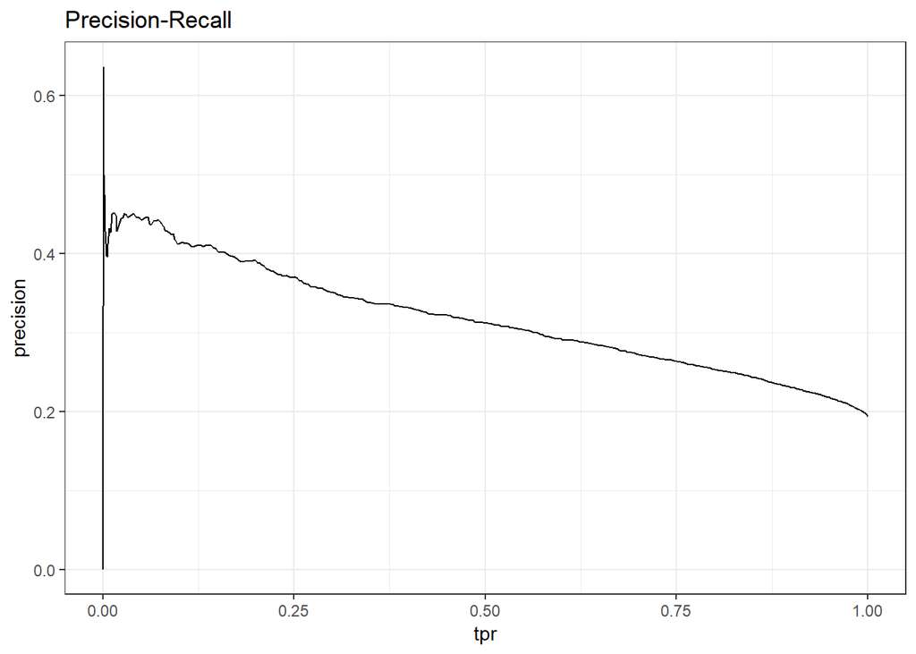

```r
ggplot(PR_out, aes(x = tpr, y = precision)) +
  theme_bw() +
  geom_line() +
  ggtitle("Precision-Recall")
```

# Conclusion

Sampling of the data has a direct effect on the overal performance of the AUC values created by the model. The difference in AUC results from undersampling to oversampling of the datasets can cause a 6.7% change in the AUC score, and 2.8% just from undersampling (difference from no over or under sampling techniques). Therefore, while it is important to get the exact correct sampling ratio on an imbalanced dataset, in order to get a higher score than .67 of AUC on the response variable,the features used will need more engineering on them.

The range in AUC values different models ran was between:

##AUC

#### No imbalance in sample

**0.6388367**: No under or oversampling attempted on data

#### Smallest AUC from oversampling

**0.5943416**: Oversampling of the response variable my a margin of 9 to 1

The other performance metrics were interesting to interpret in their variability. All of these additional metrics had an interesting impact.

## Gini

Overall- by taking the variables in the mortgage dataset and applying randomforest models showed the importance of using the right sample combination for imbalanced data. However, the general results of the variables used did not do a good job of predicting loan default due to relatively low performance metrics compared baseline measures.